# 03_alpha_diversity

Author

Hugo Maruyama

Published

March 6, 2026

## Introduction

Alpha diversity metrics provide insights into the internal complexity of microbial communities within individual samples. In this section, the Shannon diversity index is calculated to evaluate and compare the species-level richness and evenness captured by the Illumina MiSeq and Oxford Nanopore Technologies (ONT) platforms.

## Environment Setup

The `vegan` package, a standard tool for community ecology analysis, is utilized to compute the diversity indices.

```r
library(tidyverse)
library(vegan)
library(knitr)
```

## Data Preparation for Ecological Analysis

The `vegan` package requires input data in a specific format where samples are represented as rows and taxa as columns. A transformation function is implemented to prepare the harmonized datasets for diversity calculation.

```r
# Load the processed data objects from the previous module
illumina_processed <- readRDS("processed_data/illumina_processed.rds")
nanopore_processed <- readRDS("processed_data/nanopore_processed.rds")

# Function to transform the taxonomic tables for 'vegan' compatibility
prepare_for_vegan <- function(df) {
  df %>%
    # Filter for species-level assignments and remove NAs
    dplyr::filter(!is.na(species)) %>%
    # Aggregate abundances by species name to handle potential duplicates
    dplyr::group_by(species) %>%
    dplyr::summarise(dplyr::across(where(is.numeric), sum), .groups = 'drop') %>%
    # Set species as row identifiers
    tibble::column_to_rownames("species") %>%
    # Transpose to sample-by-taxa format
    t()
}

illumina_for_vegan <- prepare_for_vegan(illumina_processed)
nanopore_for_vegan <- prepare_for_vegan(nanopore_processed)
```

## Alpha Diversity Calculation

The Shannon diversity index is computed for each sample across both sequencing platforms.

```r
# Compute Shannon diversity index
shannon_illumina <- diversity(illumina_for_vegan, index = "shannon")
shannon_nanopore <- diversity(nanopore_for_vegan, index = "shannon")

# Consolidate results into a tidy data frame for analysis and visualization
alpha_diversity_summary <- tibble(
  Sample = c(names(shannon_illumina), names(shannon_nanopore)),
  Sequencer = factor(c(rep("Illumina MiSeq", 4), rep("Oxford Nanopore", 4)),
                     levels = c("Illumina MiSeq", "Oxford Nanopore")),
  Shannon = c(shannon_illumina, shannon_nanopore)
)

# Display the diversity summary
kable(alpha_diversity_summary, caption = "Shannon Diversity Index by Sample and Platform")
```

Shannon Diversity Index by Sample and Platform

| Sample | Sequencer | Shannon |
| --- | --- | --- |
| AP | Illumina MiSeq | 3.026616 |
| BP | Illumina MiSeq | 3.325635 |
| AS | Illumina MiSeq | 3.607782 |
| BS | Illumina MiSeq | 2.824451 |
| AP | Oxford Nanopore | 2.032628 |
| BP | Oxford Nanopore | 2.738957 |
| AS | Oxford Nanopore | 3.282738 |
| BS | Oxford Nanopore | 2.036280 |

## Statistical Analysis

To determine if there is a significant difference in the alpha diversity captured by the two platforms, a paired Wilcoxon signed-rank test is performed. This non-parametric test is appropriate for comparing paired samples (same biological material sequenced on different platforms).

```r
# Extract values for the paired test
shannon_illumina_values <- alpha_diversity_summary %>%
  dplyr::filter(Sequencer == "Illumina MiSeq") %>%
  dplyr::pull(Shannon)

shannon_nanopore_values <- alpha_diversity_summary %>%
  dplyr::filter(Sequencer == "Oxford Nanopore") %>%
  dplyr::pull(Shannon)

# Perform paired Wilcoxon signed-rank test
wilcox_test_result <- wilcox.test(shannon_illumina_values, shannon_nanopore_values, paired = TRUE)

# Print test results
print(wilcox_test_result)
```

```
    Wilcoxon signed rank exact test

data:  shannon_illumina_values and shannon_nanopore_values
V = 10, p-value = 0.125
alternative hypothesis: true location shift is not equal to 0
```

## Visualization

The distribution of Shannon diversity indices is visualized using boxplots overlaid with individual data points to provide a comprehensive view of the platform-specific variance.

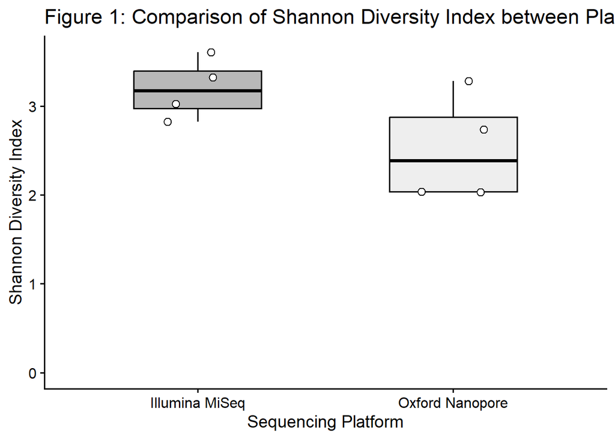

```r
# Create the publication-quality plot
alpha_diversity_plot <- ggplot(alpha_diversity_summary, aes(x = Sequencer, y = Shannon, fill = Sequencer)) +
  geom_boxplot(
    width = 0.5,
    color = "black",
    alpha = 0.7,
    outlier.shape = NA
  ) +
  scale_y_continuous(limits = c(0, NA)) +
  geom_jitter(width = 0.15, height = 0, size = 2.5, shape = 21, fill = "white") +
  scale_fill_grey(start = 0.6, end = 0.9) +
  labs(
    title = "Figure 1: Comparison of Shannon Diversity Index between Platforms",
    x = "Sequencing Platform",
    y = "Shannon Diversity Index"
  ) +
  theme_classic(base_size = 14) +
  theme(
    axis.text = element_text(size = 12),
    axis.title = element_text(size = 14),
    legend.position = "none"
  )

# Ensure the output directory exists
if (!dir.exists("figures")) {
  dir.create("figures")
}

# Save the plot for publication
ggsave(
  filename = "figures/fig1_alpha_diversity_comparison.png",
  plot = alpha_diversity_plot,
  width = 6,
  height = 5,
  dpi = 300
)

# Display the plot
alpha_diversity_plot
```

**Note:** This visualization corresponds to **Figure 1** in the main manuscript (Exported as `fig1_alpha_diversity_comparison.png`).

## Summary of Findings

The alpha diversity analysis reveals the comparative performance of Illumina and Nanopore sequencing in characterizing the complexity of the 16S rRNA gene library. The statistical results indicate whether the observed differences in Shannon diversity are significant, which is a key consideration for interpreting the taxonomic resolution provided by each platform.